# Risk Factor Analysis

## Outcome Variable

**Outcome Variable:** stunted

## Predictor Variables

**Intervention Variable:** cleanck

**Adjustment Set:**

- arm
- sex
- W_mage
- meducyrs
- feducyrs
- hhwealth_quart
- W_nrooms
- W_nhh
- W_nchldlt5
- trth2o
- impfloor
- delta_meducyrs
- delta_feducyrs
- delta_hhwealth_quart
- delta_W_nrooms
- delta_W_nhh
- delta_W_nchldlt5
- delta_trth2o
- delta_impfloor

## Stratifying Variables

The analysis was stratified on these variable(s):

- agecat
- studyid
- country

## Data Summary

| agecat | studyid | country | cleanck | stunted | n_cell | n |
| --- | --- | --- | --- | --- | --- | --- |
| Birth | CMC-V-BCS-2002 | INDIA | 1 | 0 | 35 | 92 |
| Birth | CMC-V-BCS-2002 | INDIA | 1 | 1 | 4 | 92 |
| Birth | CMC-V-BCS-2002 | INDIA | 0 | 0 | 40 | 92 |
| Birth | CMC-V-BCS-2002 | INDIA | 0 | 1 | 13 | 92 |
| Birth | GMS-Nepal | NEPAL | 1 | 0 | 9 | 621 |
| Birth | GMS-Nepal | NEPAL | 1 | 1 | 0 | 621 |
| Birth | GMS-Nepal | NEPAL | 0 | 0 | 506 | 621 |
| Birth | GMS-Nepal | NEPAL | 0 | 1 | 106 | 621 |
| Birth | IRC | INDIA | 1 | 0 | 197 | 378 |
| Birth | IRC | INDIA | 1 | 1 | 21 | 378 |
| Birth | IRC | INDIA | 0 | 0 | 138 | 378 |
| Birth | IRC | INDIA | 0 | 1 | 22 | 378 |
| Birth | MAL-ED | PERU | 1 | 0 | 1 | 2 |
| Birth | MAL-ED | PERU | 1 | 1 | 0 | 2 |
| Birth | MAL-ED | PERU | 0 | 0 | 1 | 2 |
| Birth | MAL-ED | PERU | 0 | 1 | 0 | 2 |
| Birth | NIH-Crypto | BANGLADESH | 1 | 0 | 301 | 561 |
| Birth | NIH-Crypto | BANGLADESH | 1 | 1 | 44 | 561 |
| Birth | NIH-Crypto | BANGLADESH | 0 | 0 | 183 | 561 |
| Birth | NIH-Crypto | BANGLADESH | 0 | 1 | 33 | 561 |
| Birth | PROVIDE | BANGLADESH | 1 | 0 | 400 | 539 |
| Birth | PROVIDE | BANGLADESH | 1 | 1 | 38 | 539 |
| Birth | PROVIDE | BANGLADESH | 0 | 0 | 91 | 539 |
| Birth | PROVIDE | BANGLADESH | 0 | 1 | 10 | 539 |
| 6 months | CMC-V-BCS-2002 | INDIA | 1 | 0 | 123 | 369 |
| 6 months | CMC-V-BCS-2002 | INDIA | 1 | 1 | 40 | 369 |
| 6 months | CMC-V-BCS-2002 | INDIA | 0 | 0 | 135 | 369 |
| 6 months | CMC-V-BCS-2002 | INDIA | 0 | 1 | 71 | 369 |
| 6 months | GMS-Nepal | NEPAL | 1 | 0 | 8 | 505 |
| 6 months | GMS-Nepal | NEPAL | 1 | 1 | 0 | 505 |
| 6 months | GMS-Nepal | NEPAL | 0 | 0 | 388 | 505 |
| 6 months | GMS-Nepal | NEPAL | 0 | 1 | 109 | 505 |
| 6 months | IRC | INDIA | 1 | 0 | 181 | 398 |
| 6 months | IRC | INDIA | 1 | 1 | 49 | 398 |
| 6 months | IRC | INDIA | 0 | 0 | 119 | 398 |
| 6 months | IRC | INDIA | 0 | 1 | 49 | 398 |
| 6 months | MAL-ED | SOUTH AFRICA | 1 | 0 | 1 | 1 |
| 6 months | MAL-ED | SOUTH AFRICA | 1 | 1 | 0 | 1 |
| 6 months | MAL-ED | SOUTH AFRICA | 0 | 0 | 0 | 1 |
| 6 months | MAL-ED | SOUTH AFRICA | 0 | 1 | 0 | 1 |
| 6 months | NIH-Crypto | BANGLADESH | 1 | 0 | 264 | 545 |
| 6 months | NIH-Crypto | BANGLADESH | 1 | 1 | 65 | 545 |
| 6 months | NIH-Crypto | BANGLADESH | 0 | 0 | 179 | 545 |
| 6 months | NIH-Crypto | BANGLADESH | 0 | 1 | 37 | 545 |
| 6 months | PROVIDE | BANGLADESH | 1 | 0 | 429 | 604 |
| 6 months | PROVIDE | BANGLADESH | 1 | 1 | 69 | 604 |
| 6 months | PROVIDE | BANGLADESH | 0 | 0 | 79 | 604 |
| 6 months | PROVIDE | BANGLADESH | 0 | 1 | 27 | 604 |
| 24 months | CMC-V-BCS-2002 | INDIA | 1 | 0 | 67 | 371 |
| 24 months | CMC-V-BCS-2002 | INDIA | 1 | 1 | 96 | 371 |
| 24 months | CMC-V-BCS-2002 | INDIA | 0 | 0 | 38 | 371 |
| 24 months | CMC-V-BCS-2002 | INDIA | 0 | 1 | 170 | 371 |
| 24 months | GMS-Nepal | NEPAL | 1 | 0 | 5 | 435 |
| 24 months | GMS-Nepal | NEPAL | 1 | 1 | 0 | 435 |
| 24 months | GMS-Nepal | NEPAL | 0 | 0 | 232 | 435 |
| 24 months | GMS-Nepal | NEPAL | 0 | 1 | 198 | 435 |
| 24 months | IRC | INDIA | 1 | 0 | 142 | 400 |
| 24 months | IRC | INDIA | 1 | 1 | 89 | 400 |
| 24 months | IRC | INDIA | 0 | 0 | 89 | 400 |
| 24 months | IRC | INDIA | 0 | 1 | 80 | 400 |
| 24 months | MAL-ED | SOUTH AFRICA | 1 | 0 | 1 | 1 |
| 24 months | MAL-ED | SOUTH AFRICA | 1 | 1 | 0 | 1 |
| 24 months | MAL-ED | SOUTH AFRICA | 0 | 0 | 0 | 1 |
| 24 months | MAL-ED | SOUTH AFRICA | 0 | 1 | 0 | 1 |
| 24 months | NIH-Crypto | BANGLADESH | 1 | 0 | 156 | 410 |
| 24 months | NIH-Crypto | BANGLADESH | 1 | 1 | 43 | 410 |
| 24 months | NIH-Crypto | BANGLADESH | 0 | 0 | 167 | 410 |
| 24 months | NIH-Crypto | BANGLADESH | 0 | 1 | 44 | 410 |
| 24 months | PROVIDE | BANGLADESH | 1 | 0 | 338 | 578 |
| 24 months | PROVIDE | BANGLADESH | 1 | 1 | 141 | 578 |
| 24 months | PROVIDE | BANGLADESH | 0 | 0 | 50 | 578 |
| 24 months | PROVIDE | BANGLADESH | 0 | 1 | 49 | 578 |

The following strata were considered:

- agecat: 24 months, studyid: CMC-V-BCS-2002, country: INDIA
- agecat: 24 months, studyid: GMS-Nepal, country: NEPAL
- agecat: 24 months, studyid: IRC, country: INDIA
- agecat: 24 months, studyid: MAL-ED, country: SOUTH AFRICA
- agecat: 24 months, studyid: NIH-Crypto, country: BANGLADESH
- agecat: 24 months, studyid: PROVIDE, country: BANGLADESH
- agecat: 6 months, studyid: CMC-V-BCS-2002, country: INDIA
- agecat: 6 months, studyid: GMS-Nepal, country: NEPAL
- agecat: 6 months, studyid: IRC, country: INDIA
- agecat: 6 months, studyid: MAL-ED, country: SOUTH AFRICA
- agecat: 6 months, studyid: NIH-Crypto, country: BANGLADESH
- agecat: 6 months, studyid: PROVIDE, country: BANGLADESH
- agecat: Birth, studyid: CMC-V-BCS-2002, country: INDIA
- agecat: Birth, studyid: GMS-Nepal, country: NEPAL
- agecat: Birth, studyid: IRC, country: INDIA
- agecat: Birth, studyid: MAL-ED, country: PERU
- agecat: Birth, studyid: NIH-Crypto, country: BANGLADESH
- agecat: Birth, studyid: PROVIDE, country: BANGLADESH

### Dropped Strata

Some strata were dropped due to rare outcomes:

- agecat: Birth, studyid: CMC-V-BCS-2002, country: INDIA
- agecat: Birth, studyid: GMS-Nepal, country: NEPAL
- agecat: Birth, studyid: MAL-ED, country: PERU
- agecat: 6 months, studyid: GMS-Nepal, country: NEPAL
- agecat: 6 months, studyid: MAL-ED, country: SOUTH AFRICA
- agecat: 24 months, studyid: GMS-Nepal, country: NEPAL
- agecat: 24 months, studyid: MAL-ED, country: SOUTH AFRICA

## Methods Detail

We’re interested in the causal parameters $E[Y_a]$ for all values of $a \in \mathcal{A}$. These parameters represent the mean outcome if, possibly contrary to fact, we intervened to set all units to have $A=a$. Under the randomization and positivity assumptions, these are identified by the statistical parameters $\psi_a=E_W[E_{Y|A,W}(Y|A=a,W)]$. In addition, we’re interested in the mean of $Y$, $E[Y]$ under no intervention (the observed mean). We will estimate these parameters by using SuperLearner to fit the relevant likelihood factors – $E_{Y|A,W}(Y|A=a,W)$ and $p(A=a|W)$, and then updating our likelihood fit using a joint TMLE.

For unadjusted analyses ($W=\{\}$), initial likelihoods were estimated using Lrnr_glm to estimate the simple $E(Y|A)$ and Lrnr_mean to estimate $p(A)$. For adjusted analyses, a small library containing Lrnr_glmnet, Lrnr_xgboost, and Lrnr_mean was used.

Having estimated these parameters, we will then use the delta method to estimate relative risks and attributable risks relative to a prespecified baseline level of $A$.

# Results Detail

## Results Plots

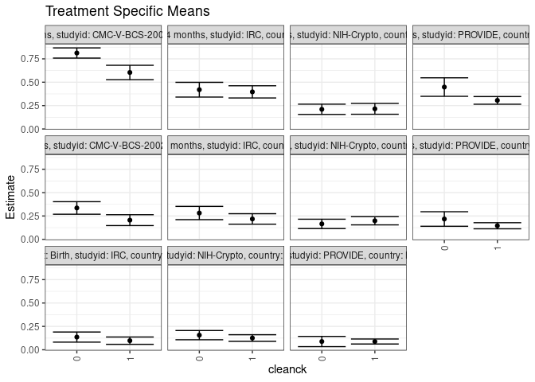

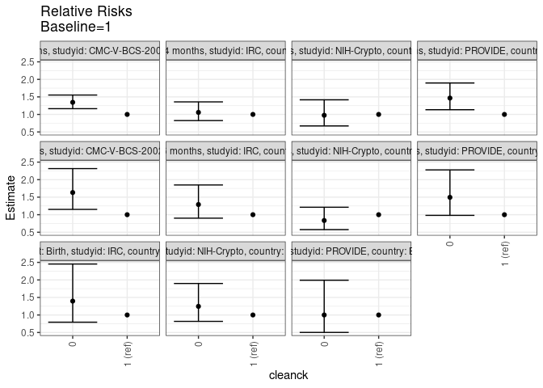

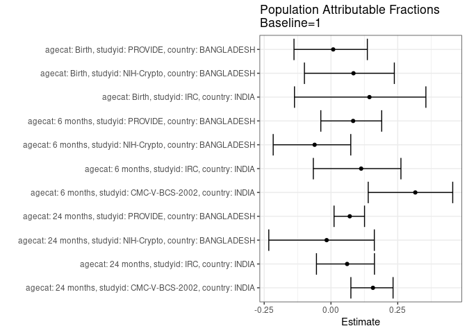

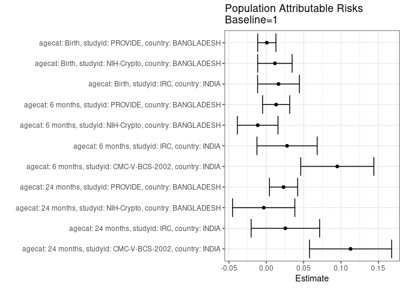

## Results Table

### Parameter: TSM

| agecat | studyid | country | intervention_level | baseline_level | estimate | ci_lower | ci_upper |
| --- | --- | --- | --- | --- | --- | --- | --- |
| Birth | IRC | INDIA | 1 | NA | 0.0973663 | 0.0582169 | 0.1365158 |
| Birth | IRC | INDIA | 0 | NA | 0.1358489 | 0.0817849 | 0.1899129 |
| Birth | NIH-Crypto | BANGLADESH | 1 | NA | 0.1256836 | 0.0905318 | 0.1608354 |
| Birth | NIH-Crypto | BANGLADESH | 0 | NA | 0.1565403 | 0.1071610 | 0.2059196 |
| Birth | PROVIDE | BANGLADESH | 1 | NA | 0.0883061 | 0.0615726 | 0.1150396 |
| Birth | PROVIDE | BANGLADESH | 0 | NA | 0.0883162 | 0.0334830 | 0.1431493 |
| 6 months | CMC-V-BCS-2002 | INDIA | 1 | NA | 0.2058226 | 0.1476453 | 0.2640000 |
| 6 months | CMC-V-BCS-2002 | INDIA | 0 | NA | 0.3360106 | 0.2691052 | 0.4029161 |
| 6 months | IRC | INDIA | 1 | NA | 0.2184011 | 0.1624122 | 0.2743901 |
| 6 months | IRC | INDIA | 0 | NA | 0.2818243 | 0.2109602 | 0.3526884 |
| 6 months | NIH-Crypto | BANGLADESH | 1 | NA | 0.1986055 | 0.1548787 | 0.2423323 |
| 6 months | NIH-Crypto | BANGLADESH | 0 | NA | 0.1657701 | 0.1156677 | 0.2158725 |
| 6 months | PROVIDE | BANGLADESH | 1 | NA | 0.1457421 | 0.1129836 | 0.1785007 |
| 6 months | PROVIDE | BANGLADESH | 0 | NA | 0.2179178 | 0.1400048 | 0.2958307 |
| 24 months | CMC-V-BCS-2002 | INDIA | 1 | NA | 0.6042359 | 0.5272818 | 0.6811900 |
| 24 months | CMC-V-BCS-2002 | INDIA | 0 | NA | 0.8125224 | 0.7580407 | 0.8670040 |
| 24 months | IRC | INDIA | 1 | NA | 0.3969318 | 0.3316143 | 0.4622494 |
| 24 months | IRC | INDIA | 0 | NA | 0.4200143 | 0.3412937 | 0.4987350 |
| 24 months | NIH-Crypto | BANGLADESH | 1 | NA | 0.2156300 | 0.1574859 | 0.2737742 |
| 24 months | NIH-Crypto | BANGLADESH | 0 | NA | 0.2103224 | 0.1555572 | 0.2650877 |
| 24 months | PROVIDE | BANGLADESH | 1 | NA | 0.3055787 | 0.2645115 | 0.3466458 |
| 24 months | PROVIDE | BANGLADESH | 0 | NA | 0.4481527 | 0.3490420 | 0.5472634 |

### Parameter: E(Y)

| agecat | studyid | country | intervention_level | baseline_level | estimate | ci_lower | ci_upper |
| --- | --- | --- | --- | --- | --- | --- | --- |
| Birth | IRC | INDIA | NA | NA | 0.1137566 | 0.0817056 | 0.1458077 |
| Birth | NIH-Crypto | BANGLADESH | NA | NA | 0.1372549 | 0.1087540 | 0.1657558 |
| Birth | PROVIDE | BANGLADESH | NA | NA | 0.0890538 | 0.0649864 | 0.1131212 |
| 6 months | CMC-V-BCS-2002 | INDIA | NA | NA | 0.3008130 | 0.2539566 | 0.3476694 |
| 6 months | IRC | INDIA | NA | NA | 0.2462312 | 0.2038529 | 0.2886094 |
| 6 months | NIH-Crypto | BANGLADESH | NA | NA | 0.1871560 | 0.1543801 | 0.2199318 |
| 6 months | PROVIDE | BANGLADESH | NA | NA | 0.1589404 | 0.1297581 | 0.1881227 |
| 24 months | CMC-V-BCS-2002 | INDIA | NA | NA | 0.7169811 | 0.6710815 | 0.7628807 |
| 24 months | IRC | INDIA | NA | NA | 0.4225000 | 0.3740325 | 0.4709675 |
| 24 months | NIH-Crypto | BANGLADESH | NA | NA | 0.2121951 | 0.1725707 | 0.2518196 |
| 24 months | PROVIDE | BANGLADESH | NA | NA | 0.3287197 | 0.2903909 | 0.3670485 |

### Parameter: RR

| agecat | studyid | country | intervention_level | baseline_level | estimate | ci_lower | ci_upper |
| --- | --- | --- | --- | --- | --- | --- | --- |
| Birth | IRC | INDIA | 1 | 1 | 1.0000000 | 1.0000000 | 1.000000 |
| Birth | IRC | INDIA | 0 | 1 | 1.3952345 | 0.7935425 | 2.453151 |
| Birth | NIH-Crypto | BANGLADESH | 1 | 1 | 1.0000000 | 1.0000000 | 1.000000 |
| Birth | NIH-Crypto | BANGLADESH | 0 | 1 | 1.2455110 | 0.8171297 | 1.898472 |
| Birth | PROVIDE | BANGLADESH | 1 | 1 | 1.0000000 | 1.0000000 | 1.000000 |
| Birth | PROVIDE | BANGLADESH | 0 | 1 | 1.0001142 | 0.5023244 | 1.991200 |
| 6 months | CMC-V-BCS-2002 | INDIA | 1 | 1 | 1.0000000 | 1.0000000 | 1.000000 |
| 6 months | CMC-V-BCS-2002 | INDIA | 0 | 1 | 1.6325251 | 1.1510739 | 2.315349 |
| 6 months | IRC | INDIA | 1 | 1 | 1.0000000 | 1.0000000 | 1.000000 |
| 6 months | IRC | INDIA | 0 | 1 | 1.2903975 | 0.9012105 | 1.847654 |
| 6 months | NIH-Crypto | BANGLADESH | 1 | 1 | 1.0000000 | 1.0000000 | 1.000000 |
| 6 months | NIH-Crypto | BANGLADESH | 0 | 1 | 0.8346703 | 0.5742762 | 1.213135 |
| 6 months | PROVIDE | BANGLADESH | 1 | 1 | 1.0000000 | 1.0000000 | 1.000000 |
| 6 months | PROVIDE | BANGLADESH | 0 | 1 | 1.4952281 | 0.9812705 | 2.278380 |
| 24 months | CMC-V-BCS-2002 | INDIA | 1 | 1 | 1.0000000 | 1.0000000 | 1.000000 |
| 24 months | CMC-V-BCS-2002 | INDIA | 0 | 1 | 1.3447105 | 1.1642368 | 1.553160 |
| 24 months | IRC | INDIA | 1 | 1 | 1.0000000 | 1.0000000 | 1.000000 |
| 24 months | IRC | INDIA | 0 | 1 | 1.0581523 | 0.8246852 | 1.357714 |
| 24 months | NIH-Crypto | BANGLADESH | 1 | 1 | 1.0000000 | 1.0000000 | 1.000000 |
| 24 months | NIH-Crypto | BANGLADESH | 0 | 1 | 0.9753856 | 0.6712671 | 1.417285 |
| 24 months | PROVIDE | BANGLADESH | 1 | 1 | 1.0000000 | 1.0000000 | 1.000000 |
| 24 months | PROVIDE | BANGLADESH | 0 | 1 | 1.4665707 | 1.1340585 | 1.896577 |

### Parameter: PAR

| agecat | studyid | country | intervention_level | baseline_level | estimate | ci_lower | ci_upper |
| --- | --- | --- | --- | --- | --- | --- | --- |
| Birth | IRC | INDIA | 1 | NA | 0.0163903 | -0.0115553 | 0.0443358 |
| Birth | NIH-Crypto | BANGLADESH | 1 | NA | 0.0115713 | -0.0114752 | 0.0346179 |
| Birth | PROVIDE | BANGLADESH | 1 | NA | 0.0007477 | -0.0114464 | 0.0129418 |
| 6 months | CMC-V-BCS-2002 | INDIA | 1 | NA | 0.0949904 | 0.0461634 | 0.1438174 |
| 6 months | IRC | INDIA | 1 | NA | 0.0278300 | -0.0124426 | 0.0681027 |
| 6 months | NIH-Crypto | BANGLADESH | 1 | NA | -0.0114495 | -0.0385884 | 0.0156894 |
| 6 months | PROVIDE | BANGLADESH | 1 | NA | 0.0131982 | -0.0049540 | 0.0313505 |
| 24 months | CMC-V-BCS-2002 | INDIA | 1 | NA | 0.1127452 | 0.0577950 | 0.1676954 |
| 24 months | IRC | INDIA | 1 | NA | 0.0255682 | -0.0202254 | 0.0713618 |
| 24 months | NIH-Crypto | BANGLADESH | 1 | NA | -0.0034349 | -0.0451161 | 0.0382462 |
| 24 months | PROVIDE | BANGLADESH | 1 | NA | 0.0231411 | 0.0043271 | 0.0419550 |

### Parameter: PAF

| agecat | studyid | country | intervention_level | baseline_level | estimate | ci_lower | ci_upper |
| --- | --- | --- | --- | --- | --- | --- | --- |
| Birth | IRC | INDIA | 1 | NA | 0.1440820 | -0.1365951 | 0.3554471 |
| Birth | NIH-Crypto | BANGLADESH | 1 | NA | 0.0843053 | -0.0993556 | 0.2372833 |
| Birth | PROVIDE | BANGLADESH | 1 | NA | 0.0083960 | -0.1384015 | 0.1362640 |
| 6 months | CMC-V-BCS-2002 | INDIA | 1 | NA | 0.3157788 | 0.1395185 | 0.4559341 |
| 6 months | IRC | INDIA | 1 | NA | 0.1130240 | -0.0660338 | 0.2620061 |
| 6 months | NIH-Crypto | BANGLADESH | 1 | NA | -0.0611763 | -0.2163122 | 0.0741726 |
| 6 months | PROVIDE | BANGLADESH | 1 | NA | 0.0830390 | -0.0379770 | 0.1899459 |
| 24 months | CMC-V-BCS-2002 | INDIA | 1 | NA | 0.1572499 | 0.0745847 | 0.2325309 |
| 24 months | IRC | INDIA | 1 | NA | 0.0605164 | -0.0543046 | 0.1628326 |
| 24 months | NIH-Crypto | BANGLADESH | 1 | NA | -0.0161876 | -0.2328322 | 0.1623862 |
| 24 months | PROVIDE | BANGLADESH | 1 | NA | 0.0703975 | 0.0115658 | 0.1257276 |